# 平均值的抽樣分布

Sampling Distribution of the Mean

Author

Tsai, Dai-Rong

# 1 中央極限定理 (Central Limit Theorem)

從平均值為 $\mu$，標準差為 $\sigma$ 的母體中，隨機地抽取大小為 $n$ 的獨立樣本。 當樣本數 $n$ 夠大時，其樣本平均值 $\bar{X}=\frac{X_1+X_2+...+X_n}{n}$ 減掉平均值 $\mu$ 再除以標準差 $\frac{\sigma}{\sqrt{n}}$，將會趨近平均值為0，標準差為1 的常態分佈 (normal distribution)。

$$\frac{\bar{X}-\mu}{\frac{\sigma}{\sqrt{n}}} \xrightarrow{n \rightarrow \infty} N(0,1)$$

# 2 Probability distributions in R

**TipDistributions in the `{stats}` package**

$$\begin{pmatrix}
\texttt{d} & \text{(probability density)} \\
\texttt{p} & \text{(cumulative distribution)} \\
\texttt{q} & \text{(quantile function)} \\
\texttt{r} & \text{(random sample)}
\end{pmatrix} \otimes \begin{pmatrix}
\texttt{unif} & \text{(Uniform)} \\
\texttt{binom} & \text{(Binomial)} \\
\texttt{pois} & \text{(Poisson)} \\
\texttt{exp} & \text{(Exponential)} \\
\texttt{norm} & \text{(Normal)} \\
\texttt{t} & \text{(Student's t)} \\
\texttt{chisq} & \text{(Chi-squared)} \\
\vdots
\end{pmatrix}$$

See `?distribution` for more distributions.

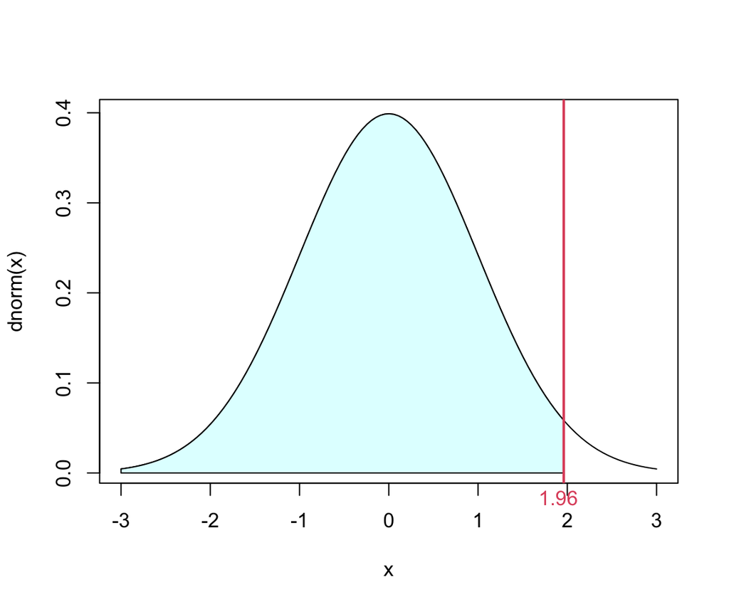

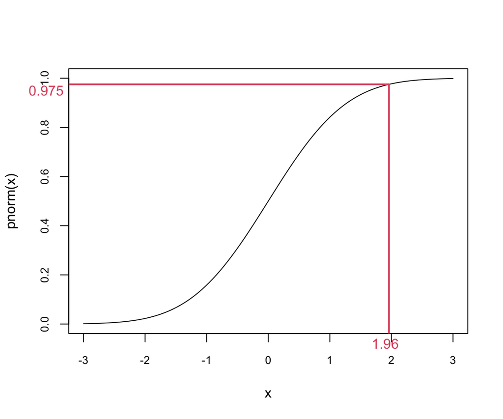

```r
pnorm(1.96)
```

```
[1] 0.9750021
```

```r
qnorm(0.975)
```

```
[1] 1.959964
```

# 3 模擬隨機抽樣

模擬從不同統計分布進行 1000 次抽樣，樣本數(sample size)分別設定 5、10、30， 計算各組抽樣結果的平均值繪製其分布圖，並與中央極限定理的理論分布做比較。

## 3.1 離散均勻分布 (Discrete uniform distribution)

模擬 1000 組投擲一顆公正骰子 5、10、30 次所出現的點數。先以 5 次為例：

1. 生成資料模擬投擲骰子的結果

   ```r
   set.seed(1)

   n <- 5    # 大小為 n 的獨立樣本
   m <- 1000 # 重複抽取 m 次

   sample_unif <- matrix(sample(1:6, size = m * n, replace = TRUE),
                         nrow = m, ncol = n)

   rownames(sample_unif) <- paste("sample", 1:m, sep = "")
   colnames(sample_unif) <- paste("obs", 1:n, sep = "")

   head(sample_unif)
   ```

   ```
           obs1 obs2 obs3 obs4 obs5
   sample1    1    4    3    4    2
   sample2    4    6    4    3    6
   sample3    1    6    6    3    6
   sample4    2    6    5    2    1
   sample5    5    1    1    6    2
   sample6    3    4    2    4    3
   ```

2. 計算平均值

   ```r
   sample_unif_mean <- rowMeans(sample_unif)
   head(sample_unif_mean)
   ```

   ```
   sample1 sample2 sample3 sample4 sample5 sample6
       2.8     4.6     4.4     3.2     3.0     3.2
   ```

   ```r
   # Equivalent:
   sample_unif_mean <- apply(sample_unif, 1, mean) # 1: by row; 2: by column
   head(sample_unif_mean)
   ```

   ```
   sample1 sample2 sample3 sample4 sample5 sample6
       2.8     4.6     4.4     3.2     3.0     3.2
   ```

**Note**

若要計算每一列的 mean，`rowMeans()` 會比 `apply(x, 1, mean)` 更有效率。 然而 `apply` 功能性更廣泛，它可以對每一列或每一行計算更複雜的統計量。例如：

```r
# Standard deviation
head(apply(sample_unif, 1, sd))
```

```
 sample1  sample2  sample3  sample4  sample5  sample6
1.303840 1.341641 2.302173 2.167948 2.345208 0.836660
```

```r
# 25th percentile
head(apply(sample_unif, 1, \(x) quantile(x, 0.25)))
```

```
sample1 sample2 sample3 sample4 sample5 sample6
      2       4       3       2       1       3
```

```r
# Mean absolute deviation
head(apply(sample_unif, 1, \(x) mean(abs(x - mean(x)))))
```

```
sample1 sample2 sample3 sample4 sample5 sample6
   1.04    1.12    1.92    1.84    2.00    0.64
```

3. 繪製分布圖並與中央極限定理的理論分布做比較

   我們先來計算中央極限定理的理論分布所需要的參數。 一顆公正骰子出現的點數服從最小值 1 最大值 6 的離散均勻分布， 其平均值與變異數分別是：

   $$\text{mean} = \frac{1+6}{2} = 3.5, ~~\text{variance} = \frac{6^2-1}{12} \approx 2.917$$
   因此中央極限定理的理論分布為 $Normal(\mu = 3.5, \sigma = \sqrt{\frac{2.917}{n}})$

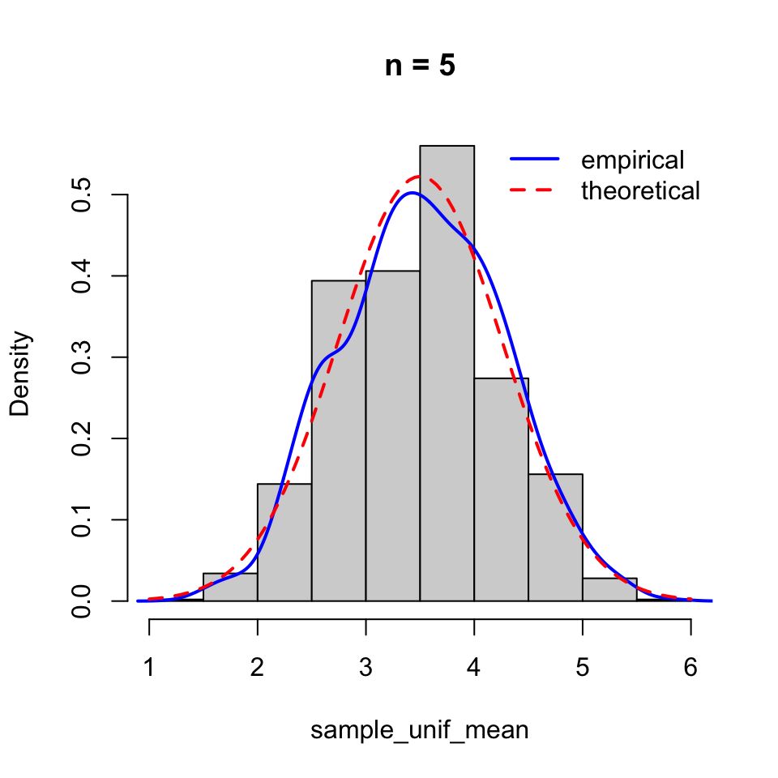

   ```r
   hist(sample_unif_mean, prob = TRUE, main = paste("n =", n))
   lines(density(sample_unif_mean), col = "blue", lwd = 2)
   curve(dnorm(x, mean = 3.5, sd = sqrt(2.917 / n)), add = TRUE,
         col = "red", lwd = 2, lty = 2)
   legend("topright", legend = c("empirical", "theoretical"),
          col = c("blue", "red"), lty = c(1, 2), lwd = 2, bty = "n")
   ```

4. 比較不同樣本數(5、10、30)下的抽樣分布

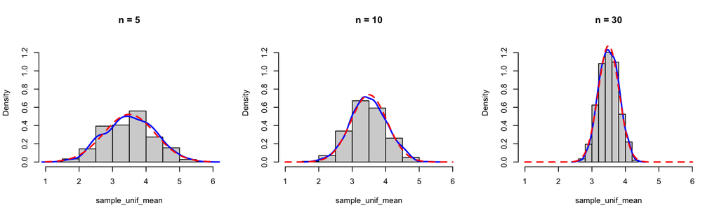

   ```r
   par(mfrow = c(1, 3))

   for(n in c(5, 10, 30)) {
     sample_unif <- matrix(sample(1:6, size = m * n, replace = TRUE),
                           nrow = m, ncol = n)
     sample_unif_mean <- rowMeans(sample_unif)
     hist(sample_unif_mean, prob = TRUE, main = paste("n =", n),
          xlim = c(1, 6), ylim = c(0, 1.3))
     lines(density(sample_unif_mean), col = "blue", lwd = 2)
     curve(dnorm(x, mean = 3.5, sd = sqrt(2.917 / n)), add = TRUE,
           col = "red", lwd = 2, lty = 2)
   }
   ```

## 3.2 二項式分布 (Binomial distribution)

模擬 1000 組同時投擲 10 枚正面機率為 0.1 的不公正銅板 5、10、30 次， 紀錄每次出現正面的次數。

```r
N <- 10
p <- 0.1
```

同時投擲 10 枚正面機率為 0.1 的不公正銅板， 出現正面的次數服從 $\text{Binomial}(N = 10, p = 0.1)$， 其平均值與變異數分別是：

$$\text{mean} = Np, ~~\text{variance} = Np(1-p)$$

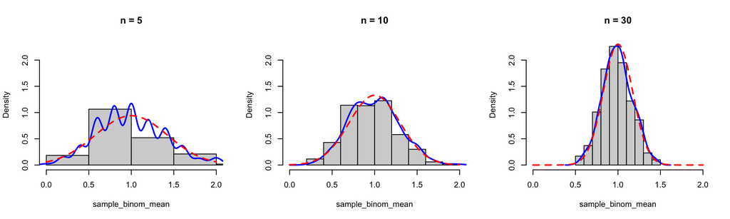

```r
par(mfrow = c(1, 3))

for(n in c(5, 10, 30)) {
  sample_binom <- matrix(rbinom(m * n, size = N, prob = p),
                         nrow = m, ncol = n)
  sample_binom_mean <- rowMeans(sample_binom)
  hist(sample_binom_mean, prob = TRUE, main = paste("n =", n),
       xlim = c(0, 2), ylim = c(0, 2.3))
  lines(density(sample_binom_mean), col = "blue", lwd = 2)
  curve(dnorm(x, mean = N*p, sd = sqrt(N*p*(1-p) / n)), add = TRUE,
        col = "red", lwd = 2, lty = 2)
}
```

## 3.3 卜瓦松分布 (Poisson distribution)

某路段一個月平均發生 2 次車禍， 模擬 1000 組 5、10、30 個月內每個月的車禍發生次數。

```r
lambda <- 2
```

某路段一個月平均發生 2 次車禍， 每個月的車禍發生次數服從 $\text{Poisson}(\lambda = 2)$， 其平均值與變異數分別是：

$$\text{mean} = \text{variance} = \lambda$$

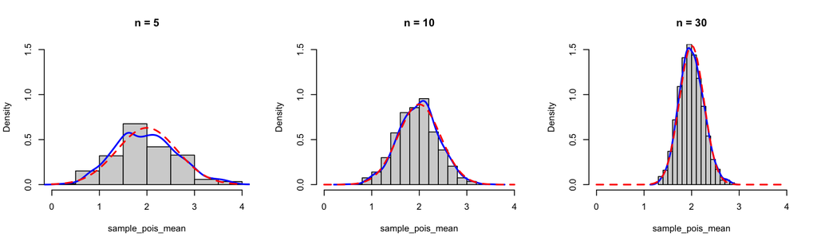

```r
par(mfrow = c(1, 3))

for(n in c(5, 10, 30)) {
  sample_pois <- matrix(rpois(m * n, lambda = lambda), # rpois(n, lambda)
                        nrow = m, ncol = n)
  sample_pois_mean <- rowMeans(sample_pois)
  hist(sample_pois_mean, prob = TRUE, main = paste("n =", n),
       xlim = c(0, 4), ylim = c(0, 1.5))
  lines(density(sample_pois_mean), col = "blue", lwd = 2)
  curve(dnorm(x, mean = lambda, sd = sqrt(lambda / n)), add = TRUE,
        col = "red", lwd = 2, lty = 2)
}
```

## Exercise (1)

若大學畢業生的平均月薪資是 $25,000，標準差是 $5,000。

1. 若隨機選取 100 名畢業生，這些人的平均薪資超過 $26,000 的機會有多大?

   $$\mu = 25000, ~ \sigma = 5000$$
   所以 $\bar{X}$ 的期望值是 $25,000，而 $\bar{X}$ 的抽樣分布的標準差， 也就是標準誤(standard error)為

   $$se = \frac{\sigma}{\sqrt{n}} = \frac{5000}{\sqrt{100}} = 500$$

   根據中央極限定理，$\bar{X} \sim \text{Normal}(25000, 500)$，所以

   $$P(\bar{X} > 26000) = P(Z > \frac{26000 - 25000}{500}) = P(Z > 2)$$
   表示 $\bar{X} = 26,000$ 比期望值 25,000 超過 2 個標準差。 以下指令都可以求出 $Z > 2$ 的機率：

   ```r
   1 - pnorm(26000, mean = 25000, sd = 500)
   ```

   ```
   [1] 0.02275013
   ```

   ```r
   pnorm(26000, mean = 25000, sd = 500, lower.tail = FALSE)
   ```

   ```
   [1] 0.02275013
   ```

   ```r
   1 - pnorm(2) # default: mean = 0, sd = 1
   ```

   ```
   [1] 0.02275013
   ```

   ```r
   pnorm(2, lower.tail = FALSE)
   ```

   ```
   [1] 0.02275013
   ```

2. 若隨機選取 100 名畢業生，這些人的平均薪資在 $24,000 到 $26,000 之間的機會有多大?

   $$\begin{aligned}
   P(24000 < \bar{X} < 26000)
   &= P(\frac{24000 - 25000}{500} < Z < \frac{26000 - 25000}{500}) \\
   &= P(-2 < Z < 2) = P(Z < 2) - P(Z < -2)
   \end{aligned}$$

   ```r
   pnorm(2) - pnorm(-2)
   ```

   ```
   [1] 0.9544997
   ```

3. 若大學畢業生的月薪資服從常態分布，平均值是 $25,000，標準差未知。 若隨機選取 49 名畢業生，計算樣本標準差為 $s=3500$，這些人的平均薪資超過 $26,000 的機會有多大? 平均薪資在 $24,000 到 $26,000 之間的機會有多大?

   $$\frac{\bar{X} - \mu}{\frac{s}{\sqrt{n}}}
   = \frac{\bar{X} - 25000}{\frac{3500}{\sqrt{49}}}
   = \frac{\bar{X} - 25000}{500}\sim t_{(df=49-1)}$$

   $$P(\bar{X} > 26000) = P(T > \frac{26000 - 25000}{500}) = P(T > 2)$$

   ```r
   1 - pt(2, df = 49-1)
   ```

   ```
   [1] 0.02558797
   ```

   $$\begin{aligned}
   P(24000 < \bar{X} < 26000)
   &= P(\frac{24000 - 25000}{500} < T < \frac{26000 - 25000}{500}) \\
   &= P(-2 < T < 2)
   \end{aligned}$$

   ```r
   pt(2, df = 49-1) - pt(-2, df = 49-1)
   ```

   ```
   [1] 0.9488241
   ```

## Exercise (2)

1991 至 1995 年英國 Bristol 的兩位心臟外科醫師， 共對 181 位 5 歲以下患有先天性心臟病的小孩作矯正手術， 結果有 43 個小孩死亡。英國同時期的全國平均手術死亡率是12%。

假設 Birstol 的兩位心臟外科醫師的技術和英國其他心臟外科醫師沒有不同， 那麼在 181 次手術發生 43 次或更多次死亡的機率是多少?

```r
1 - pbinom(42, 181, 0.12)
```

```
[1] 8.296321e-06
```

```r
pbinom(42, 181, 0.12, lower.tail = FALSE)
```

```
[1] 8.296321e-06
```

```r
sum(dbinom(43:181, 181, 0.12))
```

```
[1] 8.296321e-06
```

# 4 信賴區間 (Confidence Interval)

- 利用樣本觀察值計算一個母體參數區間的上界與下界，稱為信賴界限 (confidence limits)， 使得在重複抽取樣本時，未知參數落在計算的信賴界限的比例達到需要的準確度， 稱為信賴水準 (level of confidence)。
- 一個95%信賴區間 (confidence interval) 意味著，如果我們利用 100 個來自相同的母群體的不同樣本， 計算 100 個信賴區間，我們可以期待在這100個區間裡，95 個會包含母群體平均值。
- Constructing a $(1-\alpha)100\%$ confidence interval about $\mu$
  - when $\sigma$ is known

    $$\bar{X} - z_{\alpha/2} \cdot \frac{\sigma}{\sqrt{n}} \le \mu \le
    \bar{X} + z_{\alpha/2} \cdot \frac{\sigma}{\sqrt{n}}$$
  - when $\sigma$ is unknown

    $$\bar{X} - t_{\alpha/2} \cdot \frac{s}{\sqrt{n}} \le \mu \le
    \bar{X} + t_{\alpha/2} \cdot \frac{s}{\sqrt{n}}$$

## Exercise (3)

為了想知道台灣高中男生的平均身高，我們蒐集了 12 位某市立高中男生的身高體重。 請計算台灣高中男生的平均身高的 95% 信賴區間。

```r
dat <- readxl::read_excel("data/basketball_team.xls", sheet = "sheet 1")

head(dat)
```

```
# A tibble: 6 × 4
     No Grade Height Weight
  <dbl> <dbl>  <dbl>  <dbl>
1     4     1    187     75
2     5     3    182     70
3     6     2    180     70
4     7     1    175     60
5     8     2    181     71
6     9     2    193     87
```

1. 計算身高平均值 ($\bar{X}$) 與樣本標準差 ($s$)

   ```r
   (xbar <- mean(dat$Height))
   ```

   ```
   [1] 187.9167
   ```

   ```r
   (s <- sd(dat$Height))
   ```

   ```
   [1] 8.061788
   ```

2. 由於母體標準差 $\sigma$ 未知，信賴區間需要利用 $t$ 分布推估，自由度為

$$\text{degree of freedom} = n - 1 = 12 - 1 = 11$$

3. 95% 信賴區間，$\alpha = 0.05$。若無特別註明，信賴區間一般都是指”雙尾”信賴區間， 故 $t$ 分布累計機率左右各佔 $0.05 / 2 = 0.025$。此時 $t_{\alpha/2} =$

   ```r
   qt(1 - 0.05/2, df = 12-1)
   ```

   ```
   [1] 2.200985
   ```

4. 95% 信賴區間

   ```r
   xbar + c(qt(0.025, 12-1), qt(0.975, 12-1)) * s/sqrt(12)
   ```

   ```
   [1] 182.7945 193.0389
   ```

**Note**

我們也可以用 `{stats}` 套件的 `t.test()` 函數一次計算 平均值(`$estimate`)、標準誤(`$stderr`)、信賴區間(`$conf.int`)等統計量。

```r
test_ht <- t.test(dat$Height, conf.level = 0.95)
test_ht
```

```
    One Sample t-test

data:  dat$Height
t = 80.747, df = 11, p-value < 2.2e-16
alternative hypothesis: true mean is not equal to 0
95 percent confidence interval:
 182.7945 193.0389
sample estimates:
mean of x
 187.9167
```

```r
test_ht$estimate
```

```
mean of x
 187.9167
```

```r
test_ht$stderr
```

```
[1] 2.327238
```

```r
test_ht$conf.int
```

```
[1] 182.7945 193.0389
attr(,"conf.level")
[1] 0.95
```